# Data Science Lunch and Learn: Bayesian Models

## Thomas Kealy

## 2019/10/14

This talk

- Worked example of a regression model for Radon gas.
- based on (http://www.stat.columbia.edu/~gelman/research/published/multi2.pdf)
- slides available (later on) https://tomkealy.github.io/radon/

Contents

- What is a Bayesian Heirarchical Model.
- Fully pooled model.
- Fully unpooled model.
- Partially pooled model.
- Mixed model.

Radon gas is known to be the highest cause of lung cancer in non-smokers. It is believed to be more strongly present in households containing a basement and to differ in amount present among types of soil. Radon levels vary from household to household.

The EPA did a study of radon levels in 80,000 houses. Two important predictors:

- measurement in basement or first floor (radon higher in basements).
- county uranium level (positive correlation with radon levels).

We will focus on Radon levels in Minnessota.

[figure not shown]

```python
srrs_mn, counties, county_lookup = load_data()

srrs_mn[['log_radon', 'county', 'floor', 'fips']]
```

|  | log_radon | county | floor | fips |
| --- | --- | --- | --- | --- |
| 0 | 1.163151 | AITKIN | 1 | 27001 |
| 1 | 1.163151 | AITKIN | 0 | 27001 |
| 2 | 1.360977 | AITKIN | 0 | 27001 |
| 3 | 0.693147 | AITKIN | 0 | 27001 |
| 4 | 1.410987 | ANOKA | 0 | 27003 |
| ... | ... | ... | ... | ... |
| 922 | 2.001480 | WRIGHT | 0 | 27171 |
| 923 | 1.704748 | WRIGHT | 0 | 27171 |
| 924 | 1.791759 | WRIGHT | 0 | 27171 |
| 925 | 1.547563 | YELLOW MEDICINE | 0 | 27173 |
| 926 | 1.360977 | YELLOW MEDICINE | 0 | 27173 |

919 rows × 4 columns

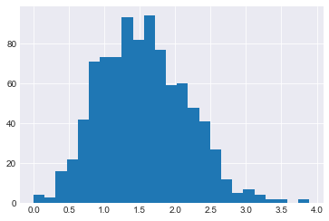

```python
srrs_mn.log_radon.hist(bins=25)
```

Linear regression:

$$ y = \alpha + \beta X + \varepsilon $$

- $y$ is the output we want to predict (or dependent variable).
- $X$ is our predictor (or independent variable).
- $\alpha$ and $\beta$ are the coefficients of the model.
- $\varepsilon$ is error term (assumed to be normally distributed).

Probabilistic reformulation:

$$ y \sim \mathcal{N}\left( \alpha + \beta X, \sigma^2 \right) $$

- we view $y$ as a random variable of which each element is distributed according to a Normal distribution.
- The mean of this normal distribution is provided by our linear predictor with variance $\sigma^2$.

While this is essentially the same model, there are two critical advantages of Bayesian estimation:

- Priors: We can quantify any prior knowledge we might have by placing priors on the paramters.

For example, if we think that σ is likely to be small we would choose a prior with more probability mass on low values.

- Quantifying uncertainty: We do not get a single estimate of $\beta$ as above but instead a complete posterior distribution about how likely different values of $\beta$ are.

For example, with few data points our uncertainty in $\beta$ will be very high and we'd be getting very wide posteriors.

One way of solving this is analytically via bayes rule:

$$ p\left(\gamma \mid y, X\right) \sim p\left(y \mid X, \gamma, \sigma^2 \right) p\left(\gamma \mid \sigma^2 \right) p\left(\sigma^2\right) $$$$ \gamma = \left(\alpha, \beta\right) $$

Once we have put priors on $\alpha$, $\beta$ we can then write down the complete model e.g.

$$ y \sim \mathcal{N}\left( \alpha + \beta X, \sigma^2 \right) $$$$ \alpha \sim \mathcal{N}\left( 0, 10\right) $$$$ \beta \sim \mathcal{N}\left( 0, 10\right) $$$$ \sigma^2 \sim \mathcal{N}\left(0, 1\right) $$

And do some scary maths.....

[figure not shown]

Or we can use PyMC3, specify a model, and use the following code:

```python
# with my_model(X=x, y=x):
#     my_trace = sample(1000)
```

### Radon: worked example

The two conventional alternatives to modeling radon exposure represent the two extremes of the bias-variance tradeoff:

### Pooled model

Treat all counties the same, estimate a single Radon level

$$ y_{i} \sim \mathcal{N}\left(\alpha + \beta X_{i}, \sigma^2\right) $$

$$ \alpha \sim \mathcal{N}\left(0, 1\right) $$$$ \beta \sim \mathcal{N}\left(0, 1\right) $$$$ \sigma \sim\mid\mathcal{N}\left(0, 5\right)\mid $$

- estimating one intercept and slope for all counties.
- i.e $X_i$ is a binary indicator of a basement present

When we pool our data, we imply that they are sampled from the same model. This ignores any variation among sampling units (other than sampling variance):

[figure not shown]

```python
from pymc3 import Model, sample, Normal, HalfCauchy, Uniform

floor = srrs_mn.floor.values
log_radon = srrs_mn.log_radon.values

@sampled
def pooled_model(X, y):
    alpha = Normal('alpha', 0, sd=1.0, shape=1)
    beta = Normal('beta', 0, sd=1.0, shape=1)
    sigma = HalfCauchy('sigma', 5)
    theta = alpha + beta*X
    y = Normal('y', theta, sd=sigma, observed=y)
```

```python
with pooled_model(X=floor, y=log_radon):
    pooled_trace = sample(1000)
```

```
Auto-assigning NUTS sampler...
Initializing NUTS using jitter+adapt_diag...
Multiprocess sampling (2 chains in 2 jobs)
NUTS: [sigma, beta, alpha]
```

[figure not shown]

```
array([<matplotlib.axes._subplots.AxesSubplot object at 0x121e38898>],
      dtype=object)
```

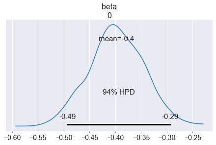

```python
plot_posterior(pooled_trace, varnames=['beta'])
```

### Unpooled model

Model radon in each county independently.

$$ y_{i,j} \sim \mathcal{N}\left( \alpha_{i,j} + \beta_{i,j} X_{i,j}, \sigma_{j}\right) $$

$$ \alpha_j \sim \mathcal{N}\left(0, 1\right) $$$$ \beta_j \sim \mathcal{N}\left(0, 1\right) $$$$ \sigma_j \sim\mid\mathcal{N}\left(0, 5\right)\mid $$

- estimating $n$ different intercepts and slopes

When we analyze data unpooled, we imply that they are sampled independently from separate models. At the opposite extreme from the pooled case, this approach claims that differences between sampling units are to large to combine them:

[figure not shown]

```python
# # #takes >45 mins!
# indiv_traces = {}
# for county_name in srrs_mn.county.unique():
#     # Select subset of data belonging to county
#     c_data = srrs_mn.ix[data.county == county_name]
#     c_data = c_data.reset_index(drop=True)

#     c_log_radon = c_data.log_radon
#     c_floor_measure = c_data.floor.values

#     with pm.Model() as individual_model:
#         # Intercept prior
#         a = pm.Normal('alpha', mu=0, sd=1)
#         # Slope prior
#         b = pm.Normal('beta', mu=0, sd=1)

#         # Model error prior
#         eps = pm.HalfCauchy('eps', beta=1)

#         # Linear model
#         radon_est = a + b * c_floor_measure

#         # Data likelihood
#         y_like = pm.Normal('y_like', mu=radon_est, sd=eps, observed=c_log_radon)

#         # Inference button (TM)!
#         trace = pm.sample(progressbar=False)

#     indiv_traces[county_name] = trace
```

[figure not shown]

Neither of these models are satisfactory:

- if we are trying to identify high-radon counties, pooling is useless
- we do not trust extreme unpooled estimates produced by models using few observations

### Heirarchical Models

Hierarchical or multilevel modeling is a generalization of regression modeling.

- A hierarchical model is a particular multilevel model where parameters are nested within one another.
- e.g. students in schools in districs in counties.

Observational units are often naturally clustered. Clustering induces dependence between observations, despite random sampling of clusters and random sampling within clusters.

E.g. There are many houses within counties.

Multilevel models are regression models

- The model parameters are given probability models.
- This implies that model parameters are allowed to vary by group.

In a hierarchical model, parameters are viewed as a sample from a population distribution of parameters. Thus, we view them as being neither entirely different or exactly the same. This is parital pooling.

[figure not shown]

```python
varying_intercept_trace
```

```
<MultiTrace: 2 chains, 1000 iterations, 7 variables>
```

### Varying Intercept and Slope

In the language of previous slides:

$$ y_{i} \sim \mathcal{N}\left( \alpha_{j[i]} + \beta_{j[i]} X, \sigma_y^2 \right)$$

$$ \alpha_j \sim \mathcal{N}\left( \mu_{\alpha}, \sigma_{\alpha}^2 \right) $$

$$ \beta_j \sim \mathcal{N}\left( \mu_{\beta}, \sigma_{\beta}^2 \right) $$

$$ \mu_{\beta} \sim \mathcal{N}\left( 0, 1 \right) $$

$$ \sigma_{\alpha} \sim\mid\mathcal{N}\left(0, 1 \right)\mid $$

$$ \sigma_{\beta} \sim\mid\mathcal{N}\left( 0, 1 \right)\mid $$

```python
@sampled
def varying_intercept_slope(X, y, groups):
    #priors
    mu_a = Normal('mu_a', mu=0., tau=0.0001)
    sigma_a = HalfCauchy('sigma_a', 5)

    mu_b = Normal('mu_b', mu=0., sd=1.)
    sigma_b = HalfCauchy('sigma_b', 5)

    # Random intercepts
    a = Normal('a', mu=mu_a, sd=sigma_a, shape=np.unique(groups).shape)

    # Random slopes
    b = Normal('b', mu=mu_b, sd=sigma_b, shape=np.unique(groups).shape)

    # Model error
    sd_y = HalfCauchy('sd_y', 5)

    # Expected value
    y_hat = a[groups] + b[groups] * X

    # Data likelihood
    y_like = Normal('y_like', mu=y_hat, sd=sd_y, observed=y)
```

```python
with varying_intercept_slope(X=floor, y=log_radon, groups=counties):
    varying_intercept_slope_trace = sample(1000, tune=1000)
```

[output not shown]

[figure not shown]

### Adding group-level predictors

A primary strength of multilevel models is the ability to handle predictors on multiple levels simultaneously. If we consider the varying-intercepts model above:

$$ y_{i} = \alpha_{j[i]}+ \beta X_i + \varepsilon_i $$

$$ \alpha \sim \mathcal{N}\left( \mu_{\alpha}, \sigma_{\alpha}^2 \right) $$

$$ \varepsilon_i \sim \mathcal{N}\left( 0, \sigma_{y}^2 \right) $$

we may, instead of a simple random effect to describe variation in the expected radon value, specify another regression model with a county-level covariate. Here, we use the county uranium reading uj, which is thought to be related to radon levels:

$$ y_{i} = \alpha_{j[i]}+ \beta X_i + \varepsilon_i $$

$$ \alpha_j \sim \mathcal{N}\left( \mu_{\alpha}, \sigma_{\alpha}^2 \right) $$

$$ \beta_j \sim \mathcal{N}\left( 0, 1 \right) $$$$ \sigma_i^2 \sim \mathcal{N}\left( 0, 1 \right) $$$$ \mu_{\alpha_{j}} = \gamma_{0}+ \gamma_1 u_j $$$$ \gamma_1 \sim \mathcal{N}\left( 0, 1 \right) $$$$ \gamma_0 \sim \mathcal{N}\left( 0, 1 \right) $$$$ \sigma_{\alpha}^2 \sim \mathcal{N}\left( 0, 1 \right) $$

Thus, we are now incorporating a house-level predictor (floor or basement) as well as a county-level predictor (uranium).

Note that the model has both indicator variables for each county, plus a county-level covariate. In classical regression, this would result in collinearity. In a multilevel model, the partial pooling of the intercepts towards the expected value of the group-level linear model avoids this.

Group-level predictors also serve to reduce group-level variation σα. An important implication of this is that the group-level estimate induces stronger pooling.

```python
from pymc3 import Deterministic

u = srrs_mn['u']

@sampled
def hierarchical_intercept(X, y, groups):
    # Priors
    sigma_a = HalfCauchy('sigma_a', 5)

    # County uranium model for slope
    gamma_0 = Normal('gamma_0', mu=0., sd=1.)
    gamma_1 = Normal('gamma_1', mu=0., sd=1.)

    # Uranium model for intercept
    mu_a = gamma_0 + gamma_1*u
    # County variation not explained by uranium
    eps_a = Normal('eps_a', mu=0, sd=sigma_a, shape=np.unique(groups).shape)
    a = Deterministic('a', mu_a + eps_a[groups])

    # Common slope
    b = Normal('b', mu=0., sd=1.)

    # Model error
    sigma_y = Uniform('sigma_y', lower=0, upper=100)

    # Expected value
    y_hat = a + b * X

    # Data likelihood
    y_like = Normal('y_like', mu=y_hat, sd=sigma_y, observed=y)
```

```python
with hierarchical_intercept(X=floor, y=log_radon, groups=counties):
    hierarchical_intercept_trace = sample(1000, tune=1000)
```

```
Auto-assigning NUTS sampler...
Initializing NUTS using jitter+adapt_diag...
Multiprocess sampling (2 chains in 2 jobs)
NUTS: [sigma_y, b, eps_a, gamma_1, gamma_0, sigma_a]
The estimated number of effective samples is smaller than 200 for some parameters.
```

[figure not shown]

### Correlations among levels

In some instances, having predictors at multiple levels can reveal correlation between individual-level variables and group residuals. We can account for this by including the average of the individual predictors as a covariate in the model for the group intercept.

$$ a_{j} = \gamma_{0}+ \gamma_1 u_j + \gamma_2 \bar{X} + \eta_j $$

These are broadly referred to as contextual effects.

```python
xbar = srrs_mn.groupby('county')['floor'].mean().rename(county_lookup).values
```

```python
@sampled
def contextual_effects(X, y, groups, mean):
    # Priors
    sigma_a = HalfCauchy('sigma_a', 5)

    # County uranium model for slope
    gamma = Normal('gamma', mu=0., sd=1e5, shape=3)

    # Uranium model for intercept
    mu_a = Deterministic('mu_a', gamma[0] + gamma[1]*u.values + gamma[2]*mean[groups])

    # County variation not explained by uranium
    eps_a = Normal('eps_a', mu=0, sd=sigma_a, shape=np.unique(groups).shape)
    a = Deterministic('a', mu_a + eps_a[groups])

    # Common slope
    b = Normal('b', mu=0., sd=1e15)

    # Model error
    sigma_y = Uniform('sigma_y', lower=0, upper=100)

    # Expected value
    y_hat = a + b * X

    # Data likelihood
    y_like = Normal('y_like', mu=y_hat, sd=sigma_y, observed=y)
```

```python
with contextual_effects(X=floor, y=log_radon, groups=counties, mean=xbar):
    contextual_effect_trace = sample(1000, tune=1000)
```

```
Auto-assigning NUTS sampler...
Initializing NUTS using jitter+adapt_diag...
Multiprocess sampling (2 chains in 2 jobs)
NUTS: [sigma_y, b, eps_a, gamma, sigma_a]
The acceptance probability does not match the target. It is 0.6641327656641858, but should be close to 0.8. Try to increase the number of tuning steps.
The estimated number of effective samples is smaller than 200 for some parameters.
```

### Prediction

In these models prediction is easy. For example, if we wanted to make a prediction for a new house with no basement in St. Louis county, we just need to sample from the radon model with the appropriate intercept:

$$ \hat{y}_{\mathrm{St. Louis}} \sim \mathcal{N}\left( \alpha_{\mathrm{St. Louis}} + \beta\left(x=1\right), \sigma_{y}^2 \right) $$

```python
with Model() as contextual_pred:

    # Priors
    sigma_a = HalfCauchy('sigma_a', 5)

    # County uranium model for slope
    gamma = Normal('gamma', mu=0., sd=1e5, shape=3)

    # Uranium model for intercept
    mu_a = Deterministic('mu_a', gamma[0] + gamma[1]*u.values + gamma[2]*xbar[counties])

    # County variation not explained by uranium
    eps_a = Normal('eps_a', mu=0, sd=sigma_a, shape=np.unique(counties).shape)
    a = Deterministic('a', mu_a + eps_a[counties])

    # Common slope
    b = Normal('b', mu=0., sd=1e15)

    # Model error
    sigma_y = Uniform('sigma_y', lower=0, upper=100)

    # Expected value
    y_hat = a + b * floor

    # Data likelihood
    y_like = Normal('y_like', mu=y_hat, sd=sigma_y, observed=log_radon)

    # St Louis county prediction
    stl_pred = Normal('stl_pred', mu=a[69] + b, sd=sigma_y)
```

```python
with contextual_pred:
    contextual_pred_trace = sample(1000, tune=1000)
```

```
Auto-assigning NUTS sampler...
Initializing NUTS using jitter+adapt_diag...
Multiprocess sampling (2 chains in 2 jobs)
NUTS: [stl_pred, sigma_y, b, eps_a, gamma, sigma_a]
The acceptance probability does not match the target. It is 0.8930782601029014, but should be close to 0.8. Try to increase the number of tuning steps.
There were 5 divergences after tuning. Increase `target_accept` or reparameterize.
The estimated number of effective samples is smaller than 200 for some parameters.
```

```
array([<matplotlib.axes._subplots.AxesSubplot object at 0x12feb6908>],
      dtype=object)
```

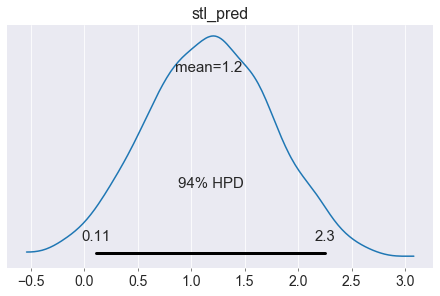

```python
plot_posterior(contextual_pred_trace, varnames=['stl_pred'])
```

Summary:

- Accounting for natural hierarchical structure of observational data
- Estimation of coefficients for (under-represented) groups
- Incorporating individual- and group-level information when estimating group-level coefficients
- Allowing for variation among individual-level coefficients across groups

## Time Series

Local Linear Trend models are one of the simplest time series models, and can be expressed by the following equations:

$$ v_t \sim N\left(v_t, \sigma_v^2\right) $$$$ x_t \sim N\left(x_{t-1} + v_{t-1}, \sigma_x^2\right) $$$$ y_t \sim N\left(x_t, \sigma_y^2\right) $$

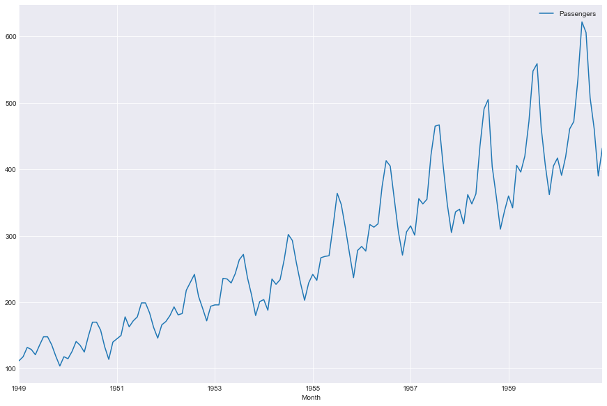

```python
passengers = pd.read_csv('passengers.csv', header=0, sep=';')
passengers['Month'] = pd.to_datetime(passengers['Month'])
passengers.set_index('Month', inplace=True)
passengers.plot(figsize=(15, 10))
```

```python
import statsmodels.api as sm

# Likelihood calculated using the state-space model
class LocalLevel(sm.tsa.statespace.MLEModel):
    def __init__(self, endog):
        # Initialize the state space model
        super(LocalLevel, self).__init__(endog, k_states=1,
                                         initialization='approximate_diffuse',
                                         loglikelihood_burn=1)

        # Initialize known components of the state space matrices
        self.ssm['design', :] = 1
        self.ssm['transition', :] = 1
        self.ssm['selection', :] = 1

    @property
    def start_params(self):
        return [1. / np.var(self.endog), 1.]

    @property
    def param_names(self):
        return ['h_inv', 'q']

    def update(self, params, transformed=True, **kwargs):
        params = super(LocalLevel, self).update(params, transformed, **kwargs)

        h, q = params
        sigma2_eps = 1. / h
        sigma2_eta = q * sigma2_eps

        self.ssm['obs_cov', 0, 0] = sigma2_eps
        self.ssm['state_cov', 0, 0] = sigma2_eta
```

```python
from pymc3 import Model, Gamma

@sampled
def local_level(value):
     # Priors
    precision = Gamma('precision', 2, 4)
    ratio = Gamma('ratio', 2, 1)

    def ll(value=value, h=precision, q=ratio):
        return value.loglike([h, q], transformed=True)
```

```python
# Instantiate the local level model with our simulated data
ll_mod = LocalLevel(passengers)
ll_mod.filter(ll_mod.start_params)

with local_level(value=ll_mod):
    ll_trace = sample(1000, tune=1000)
```

[output not shown]

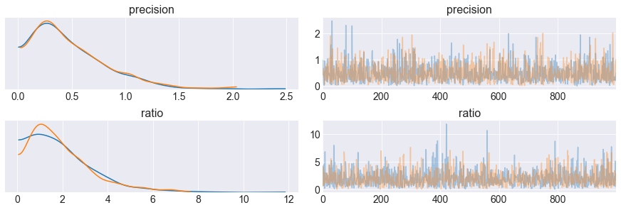

```python
traceplot(ll_trace)
```

```python
prec = ll_trace['precision'].mean(axis=0)
h = ll_trace['ratio'].mean(axis=0)
```

```python
prec
```

```
0.49946565776743235
```

```python
h
```

```
1.997909060137489
```

```python
params = prec, h
```

```python
res = ll_mod.filter(params)
```

```python
fc = res.forecast(1)
```

```python
fc
```

```
1961-01-01    427.238216
Freq: MS, dtype: float64
```

```python
passengers.iloc[-5:]
```

| Month | Passengers |
| --- | --- |
| 1960-08-01 | 606 |
| 1960-09-01 | 508 |
| 1960-10-01 | 461 |
| 1960-11-01 | 390 |
| 1960-12-01 | 432 |